# Side by Side Matrices in QToolkit

Leah Wasser

2018-05-30

## Survey Question Types

So you’ve gotten the API all setup and now you need to plot data from different types of questions. In this vignette, we will focus on the matrix and side-by-side (SBS) matrix type.

NOTE: it’s not recommended to use SBS matrices given the high cognitave load. It makes taking a survey harder for your participants. With that said, we used them ourselves before knowing better and want to ensure things don’t break on any survey that you process! So support is provided here to work with them!

To begin load all of the libraries

```r
library(qtoolkit)
library(ggplot2)
library(dplyr)
library(tidyr)
```

Connect to the API if you haven’t already!

```r
## Connect to Qualtrics API
qapi_connect()
```

And select a survey.

```r
# get a list of all surveys connected to your account / api token
all_surveys <- list_surveys()
# define survey id variable, then get survey object
survey_id <- "SV_1SUpa4C4UGkZnWB"
my_survey_ob <- qsurvey(survey_id,
                        clean_html = TRUE)
# view all questions
all_questions <- my_survey_ob$questionList
all_questions
```

```
##      qid quest_order name   type  selector subselector
## 5  QID14           5   Q7     TE        SL          NA
## 4  QID17           4   Q4     MC      SAVR          NA
## 14 QID20          14  Q31     MC      MAVR          NA
## 16 QID22          16  Q34     TE        ML          NA
## 8  QID24           8  Q14     TE      FORM          NA
## 7  QID26           7  Q10     MC      SAVR          NA
## 1  QID27           1   Q1     DB        TB          NA
## 2  QID28           2   Q2     DB        TB          NA
## 3  QID29           3   Q3     TE      FORM          NA
## 9   QID4           9  Q21 Matrix    Likert          NA
## 6  QID41           6   Q9     DB        TB          NA
## 15 QID49          15  Q33     TE        ML          NA
## 12 QID53          12  Q47     TE        ML          NA
## 10 QID54          10  Q46    SBS SBSMatrix          NA
```

[output cut: 36 more lines]

Let’s work with QID54 which is a side-by-side matrix. SBS matrices are more complex objects because it is several matrices that appear next to each other in a survey.

```r
# get responses and question information for qid71.
q54_obj <- my_survey_ob$questions$QID54
str(q54_obj)
```

```
## List of 6
##  $ meta          :'data.frame':  1 obs. of  9 variables:
##   ..$ qid        : chr "QID54"
##   ..$ order      : int 10
##   ..$ name       : chr "Q46"
##   ..$ type       : chr "SBS"
##   ..$ selector   : chr "SBSMatrix"
##   ..$ subselector: logi NA
##   ..$ text       : chr "This is a random side by side matrix table"
##   ..$ label      : logi NA
##   ..$ required   : logi FALSE
##  $ responses     :'data.frame':  15 obs. of  10 variables:
##   ..$ ResponseID: chr [1:15] "R_6PSiQWAWdqqSEtf" "R_9FCxKIEnBKINBR3" "R_3JjT9KWN1lqZM8t" "R_2nM0dGbFaaQBgLH" ...
##   ..$ Q46.1_1   : int [1:15] 2 1 1 2 2 2 2 2 2 2 ...
##   ..$ Q46.1_2   : int [1:15] 1 2 1 2 1 1 2 2 1 1 ...
##   ..$ Q46.1_3   : int [1:15] 1 2 2 2 2 2 2 1 1 1 ...
##   ..$ Q46.2_1   : int [1:15] 1 2 2 2 2 2 2 1 2 2 ...
##   ..$ Q46.2_2   : int [1:15] 1 2 1 2 2 1 1 2 1 2 ...
##   ..$ Q46.2_3   : int [1:15] 1 1 2 2 1 1 2 1 1 1 ...
##   ..$ Q46.3_1   : int [1:15] 1 2 1 2 2 1 1 2 2 2 ...
##   ..$ Q46.3_2   : int [1:15] 2 2 2 2 1 1 2 2 2 1 ...
##   ..$ Q46.3_3   : int [1:15] 1 1 1 2 1 1 2 1 2 2 ...
##  $ validation    :List of 1
##   ..$ doesForceResponse: logi FALSE
##  $ choices       :'data.frame':  6 obs. of  7 variables:
##   ..$ quest_order      : int [1:6] 1 2 1 2 1 2
##   ..$ recode           : chr [1:6] "1" "2" "1" "2" ...
##   ..$ choice_desc      : chr [1:6] "Good" "Bad" "Good" "Bad" ...
##   ..$ choice_text      : chr [1:6] "Good" "Bad" "Good" "Bad" ...
##   ..$ choice_image_desc: logi [1:6] NA NA NA NA NA NA
##   ..$ analyze          : logi [1:6] TRUE TRUE TRUE TRUE TRUE TRUE
##   ..$ col              : int [1:6] 1 1 2 2 3 3
##  $ subquestions  :'data.frame':  3 obs. of  6 variables:
##   ..$ quest_order      : int [1:3] 1 2 3
##   ..$ recode           : chr [1:3] "1" "2" "3"
##   ..$ choice_desc      : chr [1:3] "Exam 1" "Exam 2" "Exam 3"
##   ..$ choice_text      : chr [1:3] "Exam 1" "Exam 2" "Exam 3"
##   ..$ choice_var_name  : logi [1:3] NA NA NA
##   ..$ choice_image_desc: logi [1:3] NA NA NA
##  $ matrix_columns:Classes 'tbl_df', 'tbl' and 'data.frame':  1 obs. of  7 variables:
##   ..$ type       : chr "Matrix"
##   ..$ selector   : chr "Likert"
##   ..$ subSelector: chr "SingleAnswer"
##   ..$ question   : chr "How did you feel  during the middle of the test?"
##   ..$ q_label    : logi NA
##   ..$ validation : logi FALSE
##   ..$ col_num    : int 3
##  - attr(*, "class")= chr "qquestion"
```

Notice here the choices in the SBS matrix are all the same! this makes analysis easy although this type of question is still hard for your participants to take!

```r
# get responses and question information for qid71.
my_survey_ob$questions$QID54$choices
```

```
##   quest_order recode choice_desc choice_text choice_image_desc analyze col
## 1           1      1        Good        Good                NA    TRUE   1
## 2           2      2         Bad         Bad                NA    TRUE   1
## 3           1      1        Good        Good                NA    TRUE   2
## 4           2      2         Bad         Bad                NA    TRUE   2
## 5           1      1        Good        Good                NA    TRUE   3
## 6           2      2         Bad         Bad                NA    TRUE   3
```

Note below that the matrix question type has more complex column headers. This structure represents the question number `Q46`, the column number or matrix number `1` and then the sub question number `_3`.

So

`Q46.1_1`

represents question 46 (as labeled in your survey) which has the unique id QID54 in qualtrics. .1 represents matrix number one in a side by side matrix and _1 represents the first question in that matrix.

```r
# get responses and question information for qid71.
my_survey_ob$questions$QID54$responses
```

```
##           ResponseID Q46.1_1 Q46.1_2 Q46.1_3 Q46.2_1 Q46.2_2 Q46.2_3
## 1  R_6PSiQWAWdqqSEtf       2       1       1       1       1       1
## 2  R_9FCxKIEnBKINBR3       1       2       2       2       2       1
## 3  R_3JjT9KWN1lqZM8t       1       1       2       2       1       2
## 4  R_2nM0dGbFaaQBgLH       2       2       2       2       2       2
## 5  R_51g9GJUUGLhqEK1       2       1       2       2       2       1
## 6  R_cVcUE0UNdl5TA1v       2       1       2       2       1       1
## 7  R_2hJ8FELsgjruvnT       2       2       2       2       1       2
## 8  R_6A6soHvNEl7iQp7       2       2       1       1       2       1
## 9  R_baoSyQsRL95gaY5       2       1       1       2       1       1
## 10 R_cLREhCsyiSTIpXD       2       1       1       2       2       1
## 11 R_8wgXloQRIC3ruW9       2       1       2       2       1       2
## 12 R_blKovPSrJ7sumaN       1       2       2       2       1       1
## 13 R_8BolygdNiC0Lkzj       2       2       1       2       1       2
## 14 R_bmyCt9tPvdLIYHr       1       2       2       1       1       1
```

[output cut: 17 more lines]

Here are the sub questions in each matrix. Lucky for us all subquestions are always the same in a qualtrics SBS question type.

```r
# get responses and question information for qid71.
my_survey_ob$questions$QID54$subquestions
```

```
##   quest_order recode choice_desc choice_text choice_var_name
## 1           1      1      Exam 1      Exam 1              NA
## 2           2      2      Exam 2      Exam 2              NA
## 3           3      3      Exam 3      Exam 3              NA
##   choice_image_desc
## 1                NA
## 2                NA
## 3                NA
```

```r
# here, we just grab a df that has the data stacked in a way that is easily plottable
q54 <- get_question_resp(q54_obj)
head(q54)
```

```
##          ResponseID quest matrix_num subqnum response col_response
## 1 R_6PSiQWAWdqqSEtf   Q46          1       1        2          1_2
## 2 R_9FCxKIEnBKINBR3   Q46          1       1        1          1_1
## 3 R_3JjT9KWN1lqZM8t   Q46          1       1        1          1_1
## 4 R_2nM0dGbFaaQBgLH   Q46          1       1        2          1_2
## 5 R_51g9GJUUGLhqEK1   Q46          1       1        2          1_2
## 6 R_cVcUE0UNdl5TA1v   Q46          1       1        2          1_2
##   choice_order recode choice_text quest_order quest_description quest_text
## 1            2      2         Bad           1            Exam 1     Exam 1
## 2            1      1        Good           1            Exam 1     Exam 1
## 3            1      1        Good           1            Exam 1     Exam 1
## 4            2      2         Bad           1            Exam 1     Exam 1
## 5            2      2         Bad           1            Exam 1     Exam 1
## 6            2      2         Bad           1            Exam 1     Exam 1
##   choice_var_name choice_image_desc
## 1              NA                NA
## 2              NA                NA
## 3              NA                NA
## 4              NA                NA
## 5              NA                NA
## 6              NA                NA
```

Now you can plot! Below we plot responses for each matrix in it’s own ggplot facet.

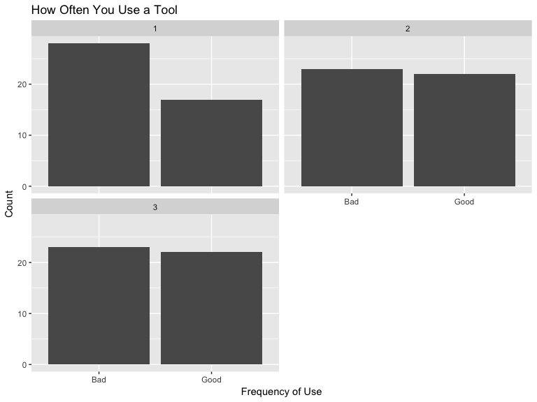

```r
# it could be nice to calculate a percentage to with some function or argument
q54 %>%
  group_by(quest_text, choice_text, matrix_num) %>%
  count() %>%
  ggplot(aes(x = choice_text, y = n)) +
  geom_bar(stat = "identity") +
  facet_wrap(~matrix_num, nrow = 2) +
  labs(title = "How Often You Use a Tool",
       x = "Frequency of Use",
       y = "Count")
```

** note that choice_rev isn’t working yet.

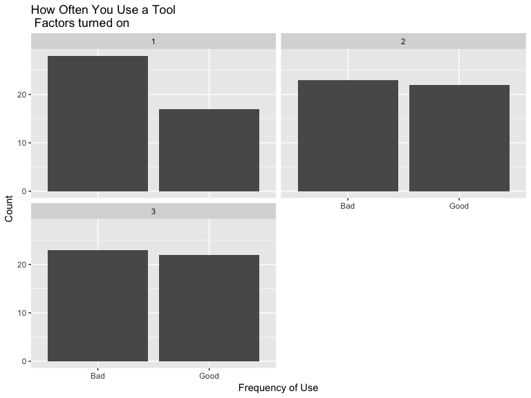

```r
# here, we just grab a df that has the data stacked in a way that is easily plottable
q54 <- get_question_resp(q54_obj,
                         choice_factor = TRUE, choice_rev = TRUE)
# it could be nice to calculate a percentage to with some function or argument
q54 %>%
  group_by(quest_text, choice_text, matrix_num) %>%
  count() %>%
  ggplot(aes(x = choice_text, y = n)) +
  geom_bar(stat = "identity") +
  facet_wrap(~matrix_num, nrow = 2) +
  labs(title = "How Often You Use a Tool\n Factors turned on",
       x = "Frequency of Use",
       y = "Count")
```

Next, let’s explore a SBS matrix where the answer options are different. First, we import and plot the data with factors set to `FALSE` (the default option).

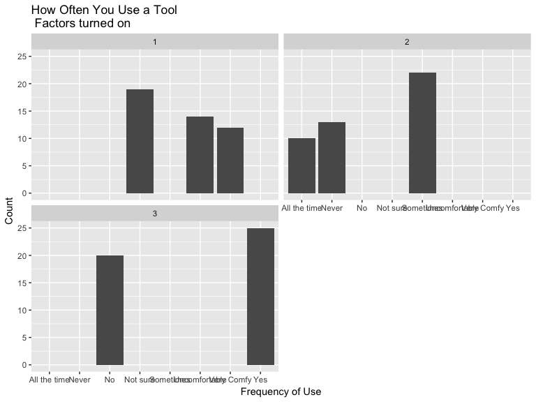

```r
# here, we just grab a df that has the data stacked in a way that is easily plottable
q55 <- get_question_resp(my_survey_ob$questions$QID55)
# it could be nice to calculate a percentage to with some function or argument
q55 %>%
  group_by(quest_text, choice_text, matrix_num) %>%
  count() %>%
  ggplot(aes(x = choice_text, y = n)) +
  geom_bar(stat = "identity") +
  facet_wrap(~matrix_num, nrow = 2) +
  labs(title = "How Often You Use a Tool\n Factors turned on",
       x = "Frequency of Use",
       y = "Count")
```

If you turn factors ON then it will return a list of data.frames - one data frame for each col in a SBS matrix.

```r
# here, we just grab a df that has the data stacked in a way that is easily plottable
q55 <- get_question_resp(my_survey_ob$questions$QID55,
                         choice_factor = TRUE)
```

```
## [1] "You are trying to process a side by side matrix that have multiple sets of choices. I've created a list containing a df for each matrix in the sbs matrix."
```

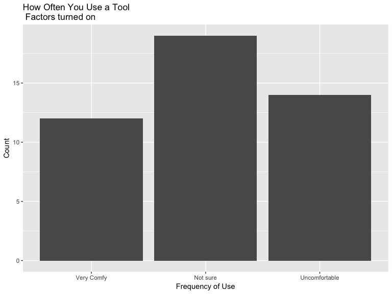

```r
# it could be nice to calculate a percentage to with some function or argument
q55[[1]] %>%
  group_by(quest_text, choice_text) %>%
  count() %>%
  ggplot(aes(x = choice_text, y = n)) +
  geom_bar(stat = "identity") +
  labs(title = "How Often You Use a Tool\n Factors turned on",
       x = "Frequency of Use",
       y = "Count")
```

Switch the order of the factor options using choice_rev.

```r
# here, we just grab a df that has the data stacked in a way that is easily plottable
q55 <- get_question_resp(my_survey_ob$questions$QID55,
                         choice_factor = TRUE,
                         choice_rev = TRUE)
```

```
## [1] "You are trying to process a side by side matrix that have multiple sets of choices. I've created a list containing a df for each matrix in the sbs matrix."
```

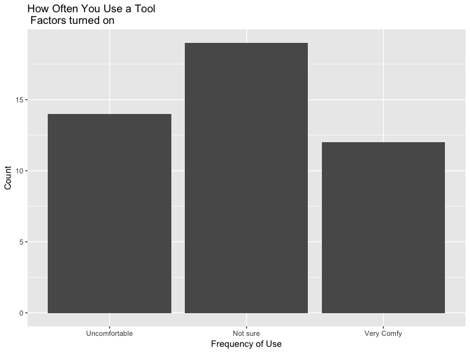

```r
# it could be nice to calculate a percentage to with some function or argument
q55[[1]] %>%
  group_by(quest_text, choice_text) %>%
  count() %>%
  ggplot(aes(x = choice_text, y = n)) +
  geom_bar(stat = "identity") +
  labs(title = "How Often You Use a Tool\n Factors turned on",
       x = "Frequency of Use",
       y = "Count")
```

In this example, you can’t use factors AND plot all matrices in one pretty plot.